# Eksport i udostępnianie notebooków

## Prosty eksport notebooków

Najprostszą opcją eksportu notebookóœ do innego formatu jest wybranie z menu `File` opcji `Download as`. Dostępne są najstępujące możliwości:

- **Notebook** - ściągamy po prostu plik z Notebookiem, przydatne jeżeli pracujemy w instancji Jupytera on-line
- **Python** - ściamy notebook jaki zwykły plik `.py`, elementy tekstowe konwertowane są do komentarzy (`#`)
- **HTML** - ściągamy notebook w pliku HTML, który potem możemy wysłać mailem/udostępnić na stronie WWW
- **Reveal.js slides** - ściągamy Notebook sformatowany jako pokaz slajdów, dodatkowe opcje dotyczące slajdów wyświetlają się po wybraniu w menu opcji View -> Cell toolbar -> Slideshow. Więcej informacji o Reveal.sj: https://revealjs.com
- **Markdown** - ściągamy notebook sformatowany jako plik Markdown
- **reST** - ściągamy notebook sformatowany jako plik ReStructured Text (podobny do Markdown)
- **LaTeX** - ściągamy notebook jako plik TeX, domyślnie nie radzi sobie z polskimi znakami ale wystarczy w LaTeXowej preambule dodać odpowiednie pakiety
- **PDF via LaTeX** - konwersja do PDF za pomocą LaTeXa (jeśli mamy zainstalowany), uwagi o polskich znakach stosują się jak wyżej.

## Zaawansowane opcje eksportu Notebooków

Wraz z pakietem Jupyter instaluje się bardzo przydatny moduł `nbconvert` który służy do konwersji Notebooków z wiersza poleceń. Oferuje trochę więcej opcji dostosowania ekspoertu do naszych potrzeb. Poniżej znajdują się przykładowe polecenia:

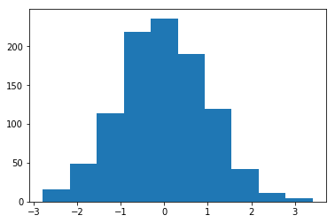

```python
# Przykładowa komórka z kodem aby zobaczyć ładny eksport.
from scipy.stats import norm
import matplotlib.pyplot as plt
%matplotlib inline
plt.hist(norm.rvs(size=1000));
```

```python
%%bash
# Prosty eksport do HTML
jupyter nbconvert --to html "03. Eksport i udostępnianie notebooków.ipynb"

# Eksport do HTML z uproszczonym kodem HTML, dobre jeśli chcemy osadzić na stronie output notebooków
# Możemy także podać nową nazwę pliku.
jupyter nbconvert --to html "03. Eksport i udostępnianie notebooków.ipynb" --template basic --output "export2.html"

# Możemy ponownie wykonać kod w komórkach (np. jeżeli używamy notebooków do automatycznego generowania raportów).
# Tu musimy wykonać inny plik, bo jeśli wykonamy ten to będzie problem :)
jupyter nbconvert --to latex "01. Podstawowe funkcje Jupyter Notebooka.ipynb" --execute --output "raport_$(date --iso).tex"
```

[output not shown]

```python
%%bash
pandoc -o "raport_$(date --iso).pdf" "raport_$(date --iso).md"
```

## Udostępnianie notebooków